# Selecting the best fit model for methylation analyses

RSTR vs. LTBI, full dataset

Kim Dill-McFarland, kadm@uw.edu

version November 10, 2022

# Setup

Load packages

```r
##Addtl tidy function
library(plyr)
# Data manipulation and figures
library(tidyverse)
  ## Multi-panel figures
  library(patchwork)
  ## Add P-values to ggplots
  library(ggpubr)
  ## kimma figures
  library(BIGpicture)

# Linear regression
library(limma)
library(kimma)

#Parallel computing
library(foreach)
library(doParallel)

#Print pretty tables to Rmd
library(knitr)
library(kableExtra)
  options(knitr.kable.NA = '')
```

Set seed

```r
set.seed(589)
```

# Load data

Load data from “EPIC array data clean-up”.

```r
#Calculate log2 ratios (M-values) from Beta
RSTR.M <- read_csv("data_Methyl_clean/RSTR_clean_M.csv.gz") %>%
  column_to_rownames("probeID")
#Probe features
probes <- read_csv("data_Methyl_clean/RSTR_probe_features.csv.gz")
#Complete metadata for methylation samples
meta <- read_csv("../data_refs/2020.11.20RSTR_Hawn_metadata.csv", na=c("",NA)) %>%
  #Keep only methylation samples
  filter(methylation == "PASS") %>%
  #Make family and name variables characters
  mutate_at(c("family.3","family.2","family.1","Sample_Name"),
            ~as.character(.)) %>%
  arrange(as.numeric(Sample_Name))
#Kinship matrix
kin <- read_csv("../data_refs/kinship_Hawn_all.csv") %>%
  #Keep methyl samples
  pivot_longer(-rowname) %>%
  filter(rowname %in% meta$FULLIDNO & name %in% meta$FULLIDNO) %>%
  pivot_wider() %>%
  column_to_rownames()
```

Verify all samples are in the same order.

```r
identical(meta$Sample_Name, colnames(RSTR.M))
```

```
## [1] TRUE
```

# Selecting metadata of interest

## Genetic relatedness

A number of study participants are blood relatives. Thus, differential methylation models may need to be corrected for relatedness. We explore 2 methods for this including 1) blocking samples by family groups or 2) including genetic kinship values (calculated from SNPs) as a random effect.

### Family blocks

Third degree relatedness includes great-grandparents, great grandchildren, great uncles/aunts, and first cousins. It corresponds to ~12.5% genetic identity.

3rd degree families with 2+ members

| Family size | Total families |
| --- | --- |
| 5 | 1 |
| 4 | 1 |
| 3 | 3 |
| 2 | 4 |

Second degree relatedness includes grandparents, grandchildren, uncles/aunts, nieces/nephews, and half-siblings. It corresponds to ~25% genetic identity.

2nd degree families with 2+ members

| Family size | Total families |
| --- | --- |
| 4 | 1 |
| 3 | 3 |
| 2 | 4 |

1st degree families with 2+ members

| Family size | Total families |
| --- | --- |
| 4 | 1 |
| 3 | 3 |
| 2 | 3 |

Here, we see that family blocks do not group in MDS of beta values.

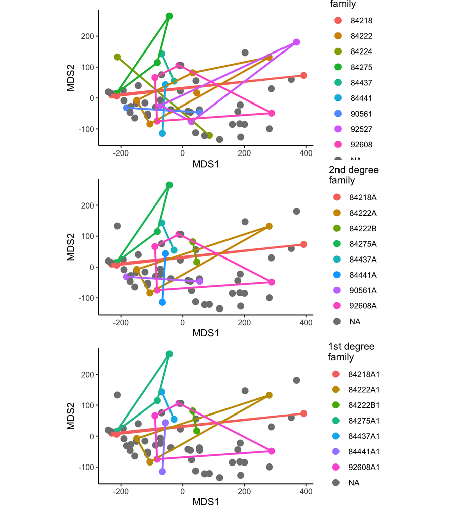

Furthermore, blocking by family groups does not improve model fit for the vast majority (> 99%) of probes. See `scripts/DMP.models.R` for running of `kmFit` models.

```
## Summary
```

```
##                          Best fit Metric Total genes Mean delta Stdev delta
## 1             lm_Sample_GroupRSTR    AIC      724737  10.062152    2.141095
## 2 lme_Sample_Group_(1 | family.1)    AIC        3643   4.642422    5.927109
```

```
## Summary
```

```
##                          Best fit Metric Total genes Mean delta Stdev delta
## 1             lm_Sample_GroupRSTR    AIC      724669  10.059208    2.143900
## 2 lme_Sample_Group_(1 | family.2)    AIC        3711   4.756619    6.089864
```

```
## Summary
```

```
##                          Best fit Metric Total genes Mean delta Stdev delta
## 1             lm_Sample_GroupRSTR    AIC      725692  10.136282    2.083651
## 2 lme_Sample_Group_(1 | family.3)    AIC        2688   4.960962    6.661378
```

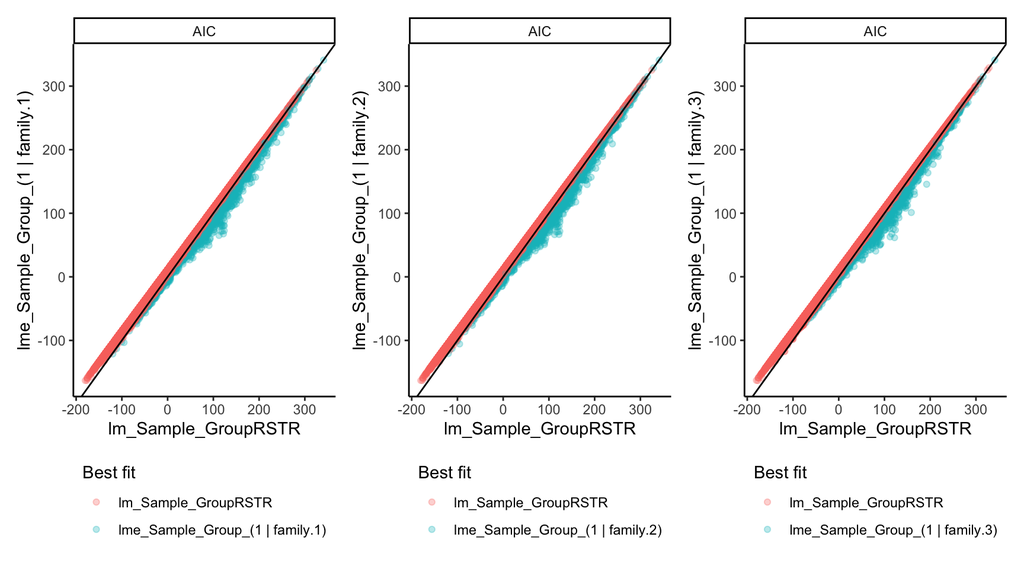

### Kinship matrix

Individuals were genotyped by Omni5 or MegaEx Chip, and pairwise kinship scores were calculated using PC-Relate in the Genesis package (Stein and Benchek). In the methylation data, 58 of 61 samples have kinship data. Of the three missing samples, 283 (RSTR) and 349 (LTBI) are not in any family blocks but 221 (RSTR) is in 84275/84275A/84275A1. Thus, these samples will be removed from analysis.

See `scripts/DMP.models.R` for running of `kmFit` models

Kinship improves model fit for a small subset of probes (~4%). It improves residuals for the majority of probes (~62%) and this improvement is much larger than without kinship (dots farther from the 1:1 line).

Given this and kinship’s use in other data set analyses, kinship will be used in all further models.

```
## Summary
```

```
##                             Best fit Metric Total genes  Mean delta Stdev delta
## 1                lm_Sample_GroupRSTR    AIC      696625 9.895741855 4.558961571
## 2 lmerel_Sample_Group_(1 | FULLIDNO)    AIC       31755 3.414541211 4.493498308
## 3                lm_Sample_GroupRSTR  sigma      277894 0.003379931 0.002752613
## 4 lmerel_Sample_Group_(1 | FULLIDNO)  sigma      450486 0.059997714 0.109850675
```

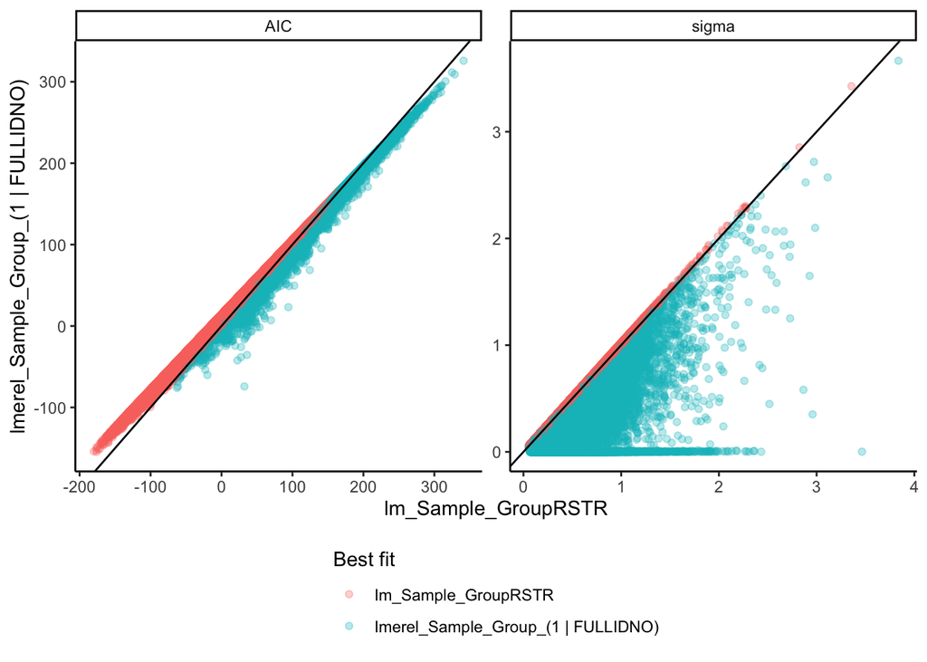

## Demographics: Age, sex, BMI

None of the metadata variables of interest differ between RSTR and LTBI groups. However, these variables may contribute to methylation profiles. Thus, additive models will be assessed in the kinship model subset. See `scripts/DMP.models.R` for running of `kmFit` models

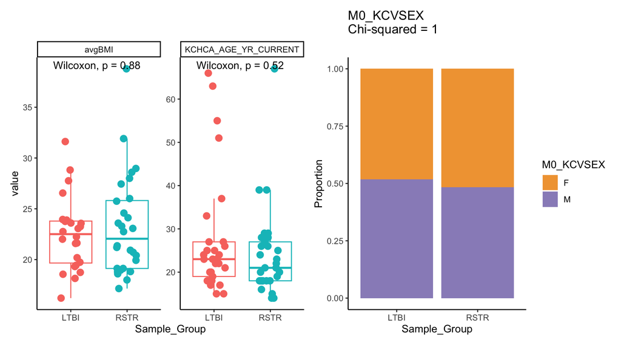

Here, we see a model with demographics improves model fit for only ~2% of genes. However, sex and age correlate with many probes at FDR $\leq$ 0.05 while BMI is significant for many fewer. In addition, global methylation is known to vary with age and sex is significant for a number of ATACseq peaks. Given these results, only sex and age will be included in further analyses.

```
## Summary
```

```
##                                                                   Best fit
## 1                                       lmerel_Sample_Group_(1 | FULLIDNO)
## 2 lmerel_Sample_Group_KCHCA_AGE_YR_CURRENT_M0_KCVSEX_avgBMI_(1 | FULLIDNO)
##   Metric Total genes Mean delta Stdev delta
## 1    AIC      713360  21.946652    8.712717
## 2    AIC       15020   5.325834    6.192175
```

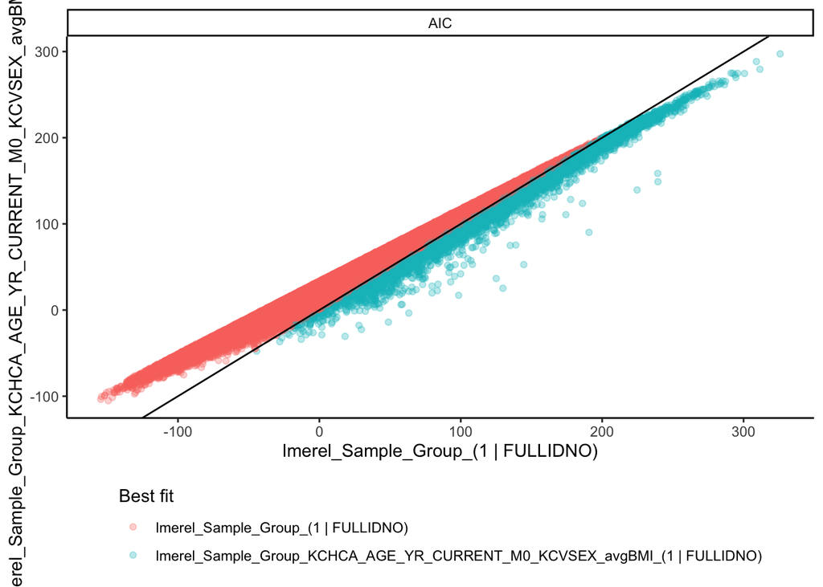

```
## # A tibble: 6 × 3
##   variable             fdr_0.05 fdr_0.2
##   <fct>                   <int>   <int>
## 1 (1 | FULLIDNO)             16      27
## 2 avgBMI                     15      43
## 3 KCHCA_AGE_YR_CURRENT     2772    6819
## 4 M0_KCVSEX                 917    2501
## 5 Sample_Group                7     101
## 6 total (nonredundant)     3715    9415
```

## TB-related: Risk, BCG

Neither TB metadata variable of interest differs between RSTR and LTBI groups. However, these variables may contribute to methylation profiles. Thus, additive models will be assessed. See `scripts/DMP.models.R` for running of `kmFit` models

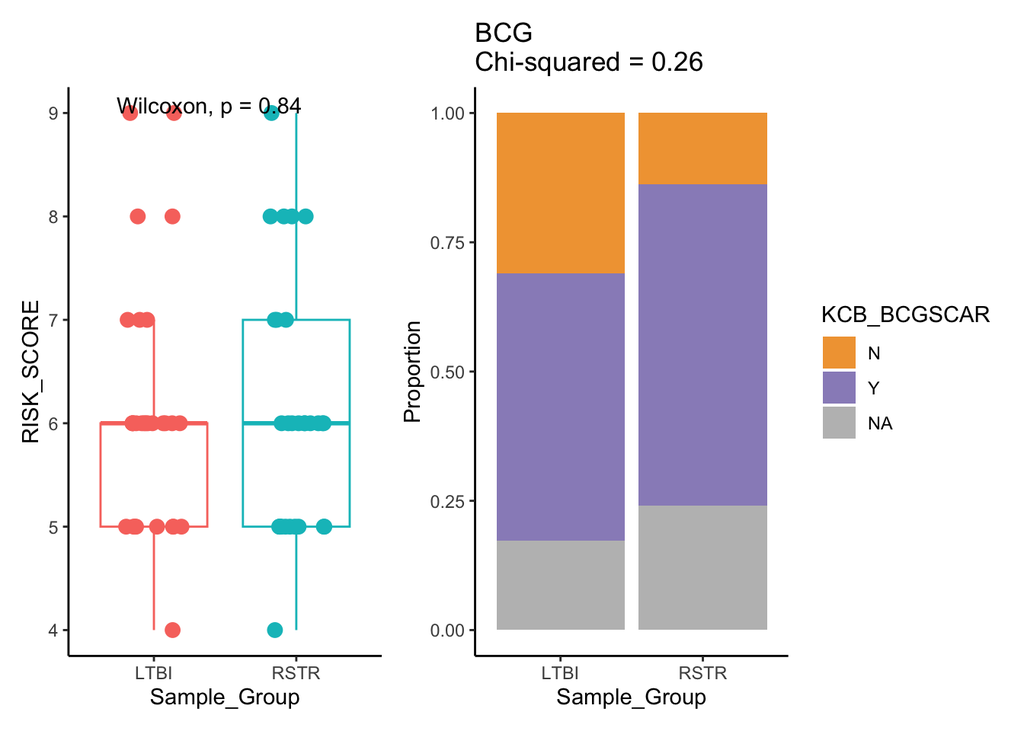

```
## Summary
```

```
##                                                                                   Best fit
## 1                 lmerel_Sample_Group_KCHCA_AGE_YR_CURRENT_M0_KCVSEX_avgBMI_(1 | FULLIDNO)
## 2 lmerel_Sample_Group_KCHCA_AGE_YR_CURRENT_M0_KCVSEX_RISK_SCORE_KCB_BCGSCAR_(1 | FULLIDNO)
##   Metric Total genes Mean delta Stdev delta
## 1    AIC      379731   6.644819    5.057403
## 2    AIC      348649   6.354360    5.278810
```

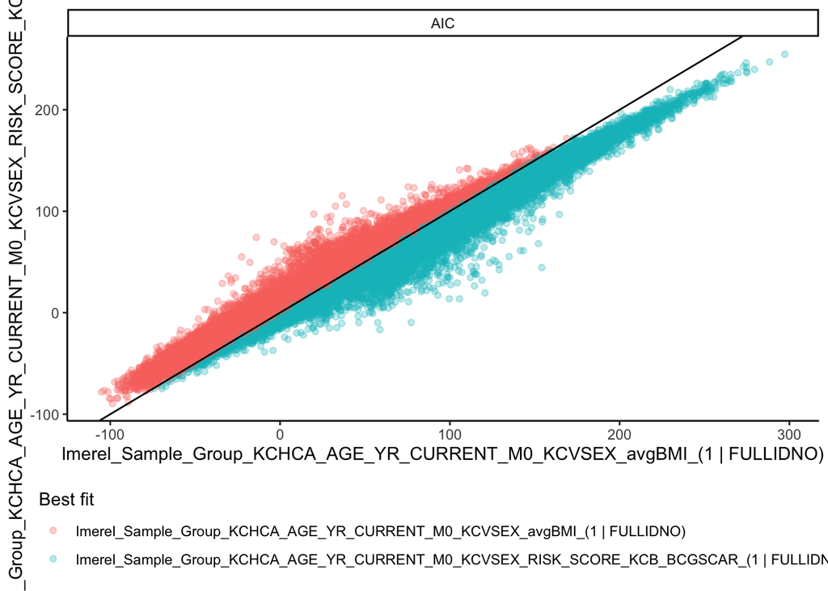

```
## # A tibble: 6 × 3
##   variable             fdr_0.05 fdr_0.2
##   <fct>                   <int>   <int>
## 1 KCB_BCGSCAR                 2      27
## 2 KCHCA_AGE_YR_CURRENT     4876   14003
## 3 M0_KCVSEX                2178    5203
## 4 RISK_SCORE                  9      39
## 5 Sample_Group               54     625
## 6 total (nonredundant)     7075   19578
```

## Model summary

`~ Sample_Group + M0_KCVSEX + KCHCA_AGE_YR_CURRENT + (1|Sample), varlist=kin`

Excluded

- Family blocks: Kinship improved model fit more as determined by AIC
- BMI: Minimal significance
- Risk score: Minimal significance
- BCG: Minimal significance, forces additional removal of samples

```r
load("results/model_selection/kinship_final_model.RData")
```

There is no strong evidence for improved model fit with or without co-variates. However, inclusion of sex and age as co-variates slightly increases the number of significant probes detected for RSTR vs. LTBI. This as well as the number of probes that are significant for the co-variates themselves leads us to conclude that the model with co-variates is the better model for these data.

```
## Summary
```

```
##                                                            Best fit Metric
## 1                                lmerel_Sample_Group_(1 | FULLIDNO)    AIC
## 2 lmerel_Sample_Group_KCHCA_AGE_YR_CURRENT_M0_KCVSEX_(1 | FULLIDNO)    AIC
##   Total genes Mean delta Stdev delta
## 1      724560  15.152039    3.042242
## 2        3820   5.622579    7.074219
```

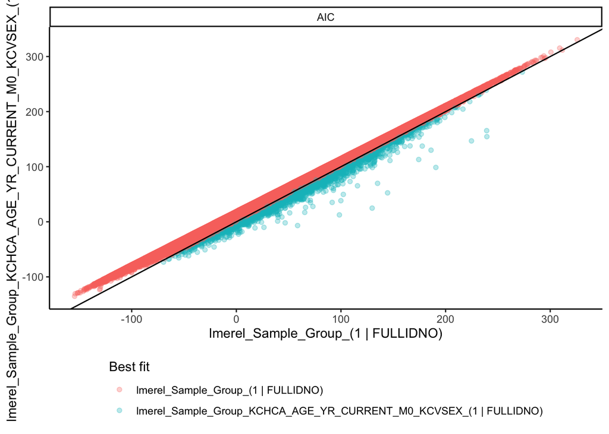

```
## # A tibble: 3 × 3
##   variable             fdr_0.05 fdr_0.2
##   <fct>                   <int>   <int>
## 1 (1 | FULLIDNO)             30      94
## 2 Sample_Group               29     140
## 3 total (nonredundant)       59     234
```

```
## # A tibble: 5 × 3
##   variable             fdr_0.05 fdr_0.2
##   <fct>                   <int>   <int>
## 1 (1 | FULLIDNO)             21      48
## 2 KCHCA_AGE_YR_CURRENT     5602   14775
## 3 M0_KCVSEX                1905    4895
## 4 Sample_Group               13     174
## 5 total (nonredundant)     7492   19577
```